# Intro R Markdown Basics

R-users at SIO

October 19, 2017

# This is a first level heading

## Lists

We can make lists

- one
  - part a
  - part b
- two
- three

or

- one
  - part a

And we can make numbered lists:

1. Numbered list item 1
2. Item 2. The numbers are incremented automatically in the output.

## Formatting text

> Blockquotes are a great way to make info stand out
> - focus on me

Italics for *emphasis* or *italics*

Bold for **more emphasis** or **bold**

## Equations

We can include equations using LaTeX notation $\mu=A_{b}*\sigma^{x^{2}}$

## Links and images

http://example.com

[linked phrase](http://example.com)

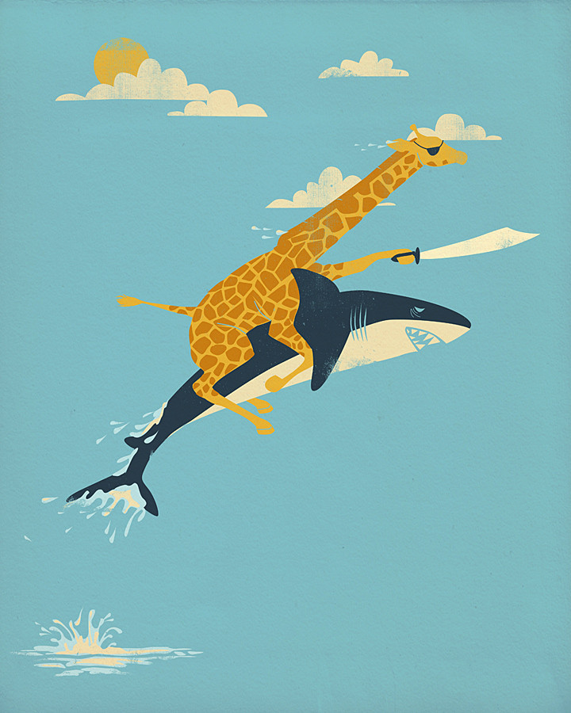

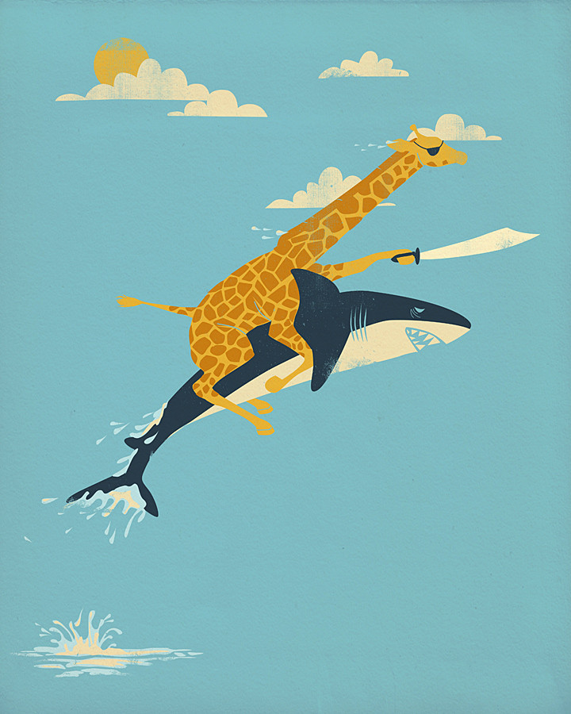

optional caption text:sharks are fun

## Tables

### Basic Tables in R-markdown

You can make tables just from R-markdown.

| First Header | Second Header |
| --- | --- |
| Content Cell | Content Cell |
| Content Cell | Content Cell |

### Tables in RMarkdown from R-chunks

You must include the option `results='asis'` in the R-chunk in order to make tables.

```r
#install packages we need, if you haven't already
#install.packages(c("knitr","xtable","stargazer"))
```

#### Tables using `kable`

`kable` enables you to make tables from knitr

```r
library(knitr)
kable(head(mtcars), digits = 2, align = c(rep("l", 4), rep("c", 4), rep("r", 4)))
```

|  | mpg | cyl | disp | hp | drat | wt | qsec | vs | am | gear | carb |
| --- | --- | --- | --- | --- | --- | --- | --- | --- | --- | --- | --- |
| Mazda RX4 | 21.0 | 6 | 160 | 110 | 3.90 | 2.62 | 16.46 | 0 | 1 | 4 | 4 |
| Mazda RX4 Wag | 21.0 | 6 | 160 | 110 | 3.90 | 2.88 | 17.02 | 0 | 1 | 4 | 4 |
| Datsun 710 | 22.8 | 4 | 108 | 93 | 3.85 | 2.32 | 18.61 | 1 | 1 | 4 | 1 |
| Hornet 4 Drive | 21.4 | 6 | 258 | 110 | 3.08 | 3.21 | 19.44 | 1 | 0 | 3 | 1 |
| Hornet Sportabout | 18.7 | 8 | 360 | 175 | 3.15 | 3.44 | 17.02 | 0 | 0 | 3 | 2 |
| Valiant | 18.1 | 6 | 225 | 105 | 2.76 | 3.46 | 20.22 | 1 | 0 | 3 | 1 |

#### Tables using `xtable`

Some people think you can make nicer tables with the `xtable` package.

```r
library(xtable)
print(xtable(head(mtcars)), type = "html")
```

|  | mpg | cyl | disp | hp | drat | wt | qsec | vs | am | gear | carb |
| --- | --- | --- | --- | --- | --- | --- | --- | --- | --- | --- | --- |
| Mazda RX4 | 21.00 | 6.00 | 160.00 | 110.00 | 3.90 | 2.62 | 16.46 | 0.00 | 1.00 | 4.00 | 4.00 |
| Mazda RX4 Wag | 21.00 | 6.00 | 160.00 | 110.00 | 3.90 | 2.88 | 17.02 | 0.00 | 1.00 | 4.00 | 4.00 |
| Datsun 710 | 22.80 | 4.00 | 108.00 | 93.00 | 3.85 | 2.32 | 18.61 | 1.00 | 1.00 | 4.00 | 1.00 |
| Hornet 4 Drive | 21.40 | 6.00 | 258.00 | 110.00 | 3.08 | 3.21 | 19.44 | 1.00 | 0.00 | 3.00 | 1.00 |
| Hornet Sportabout | 18.70 | 8.00 | 360.00 | 175.00 | 3.15 | 3.44 | 17.02 | 0.00 | 0.00 | 3.00 | 2.00 |
| Valiant | 18.10 | 6.00 | 225.00 | 105.00 | 2.76 | 3.46 | 20.22 | 1.00 | 0.00 | 3.00 | 1.00 |

#### Tables using `stargazer`

Yet another option, is the `stargazer` package.

```r
library(stargazer, quietly = TRUE)

fit1 <- lm(mpg ~ wt, mtcars)
fit2 <- lm(mpg ~ wt + hp, mtcars)
fit3 <- lm(mpg ~ wt + hp + disp, mtcars)

stargazer(fit1, fit2, fit3, type="html")
```

|  | *Dependent variable:* |  |  |
| --- | --- | --- | --- |
|  | mpg |  |  |
|  | (1) | (2) | (3) |
| wt | -5.344*** | -3.878*** | -3.801*** |
|  | (0.559) | (0.633) | (1.066) |
| hp |  | -0.032*** | -0.031** |
|  |  | (0.009) | (0.011) |
| disp |  |  | -0.001 |
|  |  |  | (0.010) |
| Constant | 37.285*** | 37.227*** | 37.106*** |
|  | (1.878) | (1.599) | (2.111) |
| Observations | 32 | 32 | 32 |
| R<sup>2</sup> | 0.753 | 0.827 | 0.827 |
| Adjusted R<sup>2</sup> | 0.745 | 0.815 | 0.808 |
| Residual Std. Error | 3.046 (df = 30) | 2.593 (df = 29) | 2.639 (df = 28) |
| F Statistic | 91.375*** (df = 1; 30) | 69.211*** (df = 2; 29) | 44.566*** (df = 3; 28) |
| *Note:* | p<0.1; p<0.05; p<0.01 |  |  |

## Figures

In general, figures will appear in a knit document exactly as they would appear in the R session. There are several important figure options to be aware of.

- `dev`, controls the graphics device used to create the figures. For example pdf, png, or jpeg. Check out tikzDevice if you are creating pdf output. The tikzDevice generates Latex code from R plots for use in Latex documents. That way, all fonts match the main text, and the Tex syntax for mathematics can be used directly in plots. Here are two examples of the power of tikzDevice: http://bit.ly/114GNdP, example
- `path` what directory to save the figures.
- `fig_width`, `fig_height`, in inches. Can also be set globally.
- `fig_align`, left, right or center.

## Getting help in R-markdown

R Markdown integrates a number of R packages and external tools. This means that help is, by-and-large, not available through `?`. Instead, as you work through this chapter, and use R Markdown in the future, keep these resources close to hand:

- R Markdown Cheat Sheet: *Help > Cheatsheets > R Markdown Cheat Sheet*,
- R Markdown Reference Guide: *Help > Cheatsheets > R Markdown Reference Guide*.

Both cheatsheets are also available at http://rstudio.com/cheatsheets.

## Additional resources

[1] http://r4ds.had.co.nz/r-markdown.html

[2] https://onlinecourses.science.psu.edu/statprogram/markdown

[3] https://sachsmc.github.io/knit-git-markr-guide/knitr/knit.html

[4] https://dereksonderegger.github.io/570L/16-rmarkdown-tricks.html

[5] https://sebastiansauer.github.io/figure_sizing_knitr/